# Iris Dataset

Gibril

# Introduction

Fisher’s Iris dataset is famous for testing different classification algorithms. It contains measurements (in cm) of sepal length and width and petal length and width, respectively, for 50 flowers of the 3 Iris species (Iris setosa, versicolor, and virginica).

The aim of this project is to use various supervised learning techniques to classify the species of a given Iris flower.

# Dataset

The dataset is freely available on the [UCI Machine Learning Repository](http://archive.ics.uci.edu/ml/datasets/Iris). It includes 50 samples of each of the three species and some measured properties about each flower. As will be seen the graphs below, one flower species can be linearly separated from the other two whereas the other two are not linearly separable from each other.

The variables in the datasets are:

- Id
- SepalLengthCm
- SepalWidthCm
- PetalLengthCm
- PetalWidthCm
- Species
  - Iris-setosa
  - Iris-versicolor
  - Iris-virginica

The graph below show the distributions and pairwise relationships of the continuous variables in the dataset.

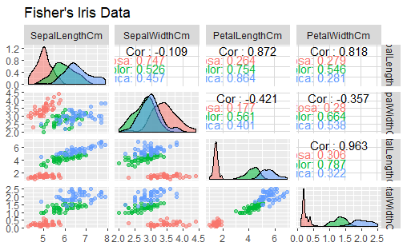